# Group Project 1

#### Do sepal and petal dimensions differ between Iris species?

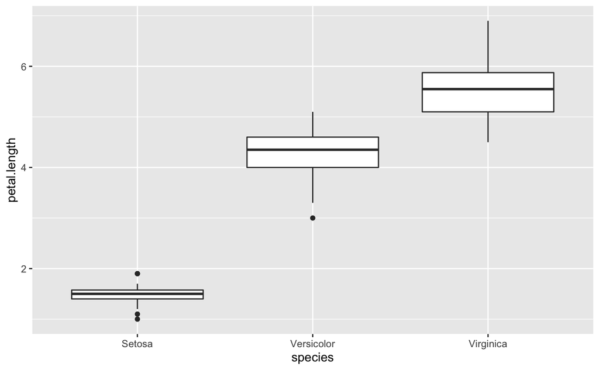

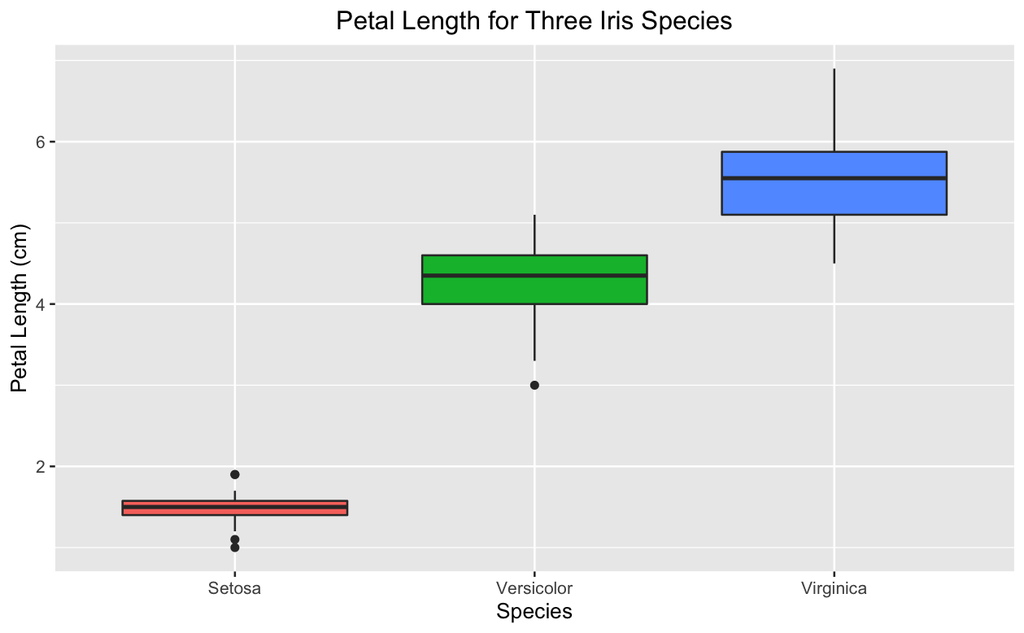

```r
ggplot(IrisData, aes(x=species, y=petal.length, fill=species)) + #Addition of fill=species adds color
  geom_boxplot() +
  labs(x = "Species", y = "Petal Length (cm)") + #Renames axes
  labs(title = "Petal Length for Three Iris Species") + #Gives plot a title
  theme(plot.title = element_text(hjust = 0.5)) + #Centers title
  theme(legend.position = "none")
```

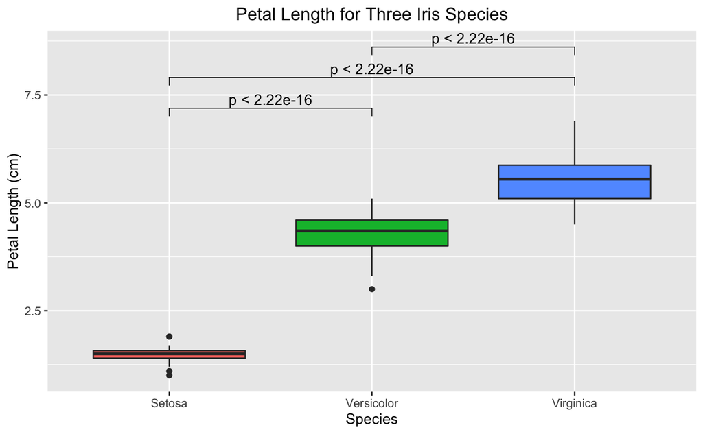

### Hypothesis Testing with Statistical Tests

Up until this point we’ve been looking at the data with some questions in mind about relationships in the data. For statistical tests, we need a specific question or hypothesis to test. Our hypothesis is that petal length differs significantly between Iris species. We will test this hypothesis below.

#### Requirements for Tests

Now we can move on to analyzing our data more critically with statistical testing for specific hypotheses. When using statistical tests, always be sure to check the assumptions made by the particular test you plan to use. This is important because many common statistical tests, including the two-sample t-test we will use here, assume that the datasets being compared are normally distributed. While much biological data is normally distributed, this is not always true, so be sure to explore and understand the behavior of your data before performing tests.

The **shapiro.test** function allows us to check if our data is normally distributed. If the data is normally distributed, the p-value returned by the shapiro test should be greater than 0.05. If there are multiple groups/populations within a data set (for example, multiple species of iris), it’s important to test for a normal distribution within each of those populations separately. Looking at the distribution as a whole may lead us to think the data is not normally distirbuted when it actually is within each population. This is actually the case for us, as you can see with the output below.

```r
shapiro.test(IrisData$petal.length) #Not normally distributed as a whole (p)
```

```
    Shapiro-Wilk normality test

data:  IrisData$petal.length
W = 0.87627, p-value = 7.412e-10
```

```r
shapiro.test(IrisData$petal.length[IrisData$species=="Setosa"]) #Normally distributed
```

```
    Shapiro-Wilk normality test

data:  IrisData$petal.length[IrisData$species == "Setosa"]
W = 0.95498, p-value = 0.05481
```

```r
shapiro.test(IrisData$petal.length[IrisData$species=="Versicolor"]) #Normally distributed
```

```
    Shapiro-Wilk normality test

data:  IrisData$petal.length[IrisData$species == "Versicolor"]
W = 0.966, p-value = 0.1585
```

```r
shapiro.test(IrisData$petal.length[IrisData$species=="Virginica"]) #Normally distributed
```

```
    Shapiro-Wilk normality test

data:  IrisData$petal.length[IrisData$species == "Virginica"]
W = 0.96219, p-value = 0.1098
```

If the data you are using is not normally distributed, test to see if a logarithmic transformation would make the distribution normal. If so, you should use the log-transformed data. If not, continue on with the original, non-transformed data but note in your report that any statistical test results should be interpreted with caution, given that the base requirements for accurate use of the test have not been met.

```r
#LogPetalLength <- log(petal.length)
```

However, each test which assumes normality also has a sample size requirement which can allow for them to produce accurate results using non-normal data. For a two-sample t-test, each group is required to have a sample size of at least 15 observations to overcome the need for normality. This cutoff is different for each type of test. Thus, if your samples fit this requirement, you can proceed without worrying about normality.

Since the data for petal length is normally distributed within each species, a log transformation is not necessary in our case. We will proceed with the non-transformed data.

#### ANOVA and Two-sample T-tests

In order to analyze whether petal length differs significantly between species, we can perform an ANOVA. We do this with the **aov()** function. It’s best to assign the function to a variable that you can then run a summary of to see the output from the ANOVA test.

```r
anova <- aov(petal.length ~ species, data = IrisData)
summary(anova)
```

```
             Df Sum Sq Mean Sq F value Pr(>F)
species       2  437.1  218.55    1180 <2e-16 ***
Residuals   147   27.2    0.19
---
Signif. codes:  0 ‘***’ 0.001 ‘**’ 0.01 ‘*’ 0.05 ‘.’ 0.1 ‘ ’ 1
```

```r
t.test(petal.length ~ species, data = SetosaVersicolor)
```

```
    Welch Two Sample t-test

data:  petal.length by species
t = -39.493, df = 62.14, p-value < 2.2e-16
alternative hypothesis: true difference in means between group Setosa and group Versicolor is not equal to 0
95 percent confidence interval:
 -2.939618 -2.656382
sample estimates:
    mean in group Setosa mean in group Versicolor
                   1.462                    4.260
```

```r
t.test(petal.length ~ species, data = SetosaVirginica)
```

```
    Welch Two Sample t-test

data:  petal.length by species
t = -49.986, df = 58.609, p-value < 2.2e-16
alternative hypothesis: true difference in means between group Setosa and group Virginica is not equal to 0
95 percent confidence interval:
 -4.253749 -3.926251
sample estimates:
   mean in group Setosa mean in group Virginica
                  1.462                   5.552
```

```r
t.test(petal.length ~ species, data = VersicolorVirginica)
```

```
    Welch Two Sample t-test

data:  petal.length by species
t = -12.604, df = 95.57, p-value < 2.2e-16
alternative hypothesis: true difference in means between group Versicolor and group Virginica is not equal to 0
95 percent confidence interval:
 -1.49549 -1.08851
sample estimates:
mean in group Versicolor  mean in group Virginica
                   4.260                    5.552
```

The results from the pairwise comparisons indicate that the mean petal length for the three species are each significantly different from one another. Thus, we have evidence to support the hypothesis that petal length differs significantly between Iris species.

### Additional Tools

#### Explanation of p-values

A p-value represents the probability that the null hypothesis is true given the outcome observed. For most purposes, a p-value of 0.05 or lower is considered statistically significant. However, staunchly relying on this value comes with some concerns, because although it is commonly used and accepted, it is essentially an arbitrary cutoff. Thus, be sure to understand what this cutoff means so you can accurately express the strength of each result.

Remember, a p-value of 0.05 means that there is a 5% chance of the observations being as they are if the null hypothesis is true. Thus, if you test 20 variables, it is statistically likely that at least one of them will show significance simply by chance.

## Grading

Each student will be expected to complete the following tasks to earn 85% of the points available for this assignment (21/25).

- Identify and obtain suitable dataset
- Use a Github repository and version control to collaborate on the project
- Spend 4-6 hours preparing, coding, and testing tutorial
  - Data exploration
  - Data visualization
  - Hypothesis testing
- Present tutorial in class
- Provide public archive suitable for sharing to students/faculty

Tutorials from previous classes can be viewed at our public github site: https://github.com/Bucknell-Biol364

Each group should use an *Acknowledgements* section to document the participation of each member and the collaboration within and between groups.

Additional credit will be awarded for providing assistance to other groups and for the development of a tutorial that goes beyond the minimal expectations listed above.

# Acknowledgements

## Group Member Contributions

1. Ian: Loading Libraries and Data, Using R, Exploring Your Data
2. Kaitlin: Tutorial screenshots, Additions to Using R, Visualization with Graphs, t-tests, Linear Models, Markdown Formatting, GitHub
3. Emily: Shapiro test, Log Transformation, p-value Discussion